# ### Nonlinear Models

Here we explore the use of nonlinear models using some tools in R

```r
library(ISLR)
names(Wage)
```

```
##  [1] "year"       "age"        "maritl"     "race"       "education"
##  [6] "region"     "jobclass"   "health"     "health_ins" "logwage"
## [11] "wage"
```

```r
dim(Wage)
```

```
## [1] 3000   11
```

```r
?Wage
```

```
## starting httpd help server ... done
```

```r
attach(Wage)
```

## Polynomials

First we will use polynomials, and focus on a single predictor age:

```r
?poly
poly_age_4 = poly(age,4)
poly_age_4 = cbind(poly_age_4, age) # poly() isn't simply raising the value of age to the 1st, 2nd, 3rd and 4th power
head(poly_age_4)
```

```
##                  1            2             3            4 age
## [1,] -0.0386247992  0.055908727 -0.0717405794  0.086729854  18
## [2,] -0.0291326034  0.026298066 -0.0145499511 -0.002599280  24
## [3,]  0.0040900817 -0.014506548 -0.0001331835  0.014480093  45
## [4,]  0.0009260164 -0.014831404  0.0045136682  0.012657507  43
## [5,]  0.0120002448 -0.009815846 -0.0111366263  0.010211456  50
## [6,]  0.0183283753 -0.002073906 -0.0166282799 -0.001314381  54
```

```r
fit=lm(wage~poly(age,4),data=Wage) # this fits a model predicting wage using a fourth degree orthogonal polynomial of age. The longer way to build this model would have been to build up a data matrix with a column for age, age squared, age cubed, and age to the fourth power, then running a regression off that matrix.
summary(fit)
```

```
##
## Call:
## lm(formula = wage ~ poly(age, 4), data = Wage)
##
## Residuals:
##     Min      1Q  Median      3Q     Max
## -98.707 -24.626  -4.993  15.217 203.693
##
## Coefficients:
##                Estimate Std. Error t value Pr(>|t|)
## (Intercept)    111.7036     0.7287 153.283  < 2e-16 ***
## poly(age, 4)1  447.0679    39.9148  11.201  < 2e-16 ***
## poly(age, 4)2 -478.3158    39.9148 -11.983  < 2e-16 ***
## poly(age, 4)3  125.5217    39.9148   3.145  0.00168 **
## poly(age, 4)4  -77.9112    39.9148  -1.952  0.05104 .
## ---
## Signif. codes:  0 '***' 0.001 '**' 0.01 '*' 0.05 '.' 0.1 ' ' 1
##
## Residual standard error: 39.91 on 2995 degrees of freedom
## Multiple R-squared:  0.08626,    Adjusted R-squared:  0.08504
## F-statistic: 70.69 on 4 and 2995 DF,  p-value: < 2.2e-16
```

We see that the coefficients, they’re all named poly age 4, and then 1, 2, 3, and 4. This will be for degree 1, 2, 3, and 4, the different degree monomials. The first two are very significant, the cubic is significant, and the quartic is just barely not significant. So it seems like a cubic polynomial would be sufficient. Now normally, when you have a whole matrix, you can’t just look at these coefficients independently. Usually what it means is the effect of, say, this coefficient in the presence of all the others, and if the variables are correlated, you just can’t make sequential decisions. But here, it’s a little different, and that’s because the function, poly, generates *orthogonal polynomials* (any two different polynomials in the sequence are orthogonal to each other). So it’s like we’re doing a regression with uncorrelated predictors.

Lets make a plot of the fitted function, along with the standard errors of the fit.

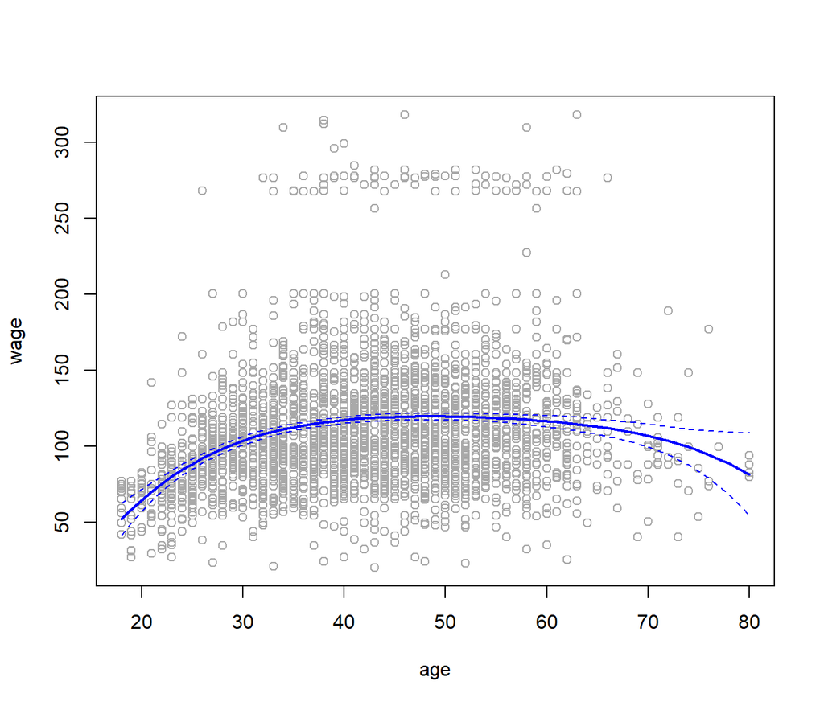

```r
agelims=range(age) # returns a vector of length 2, containing the minimum and maxium of age
age.grid=seq(from=agelims[1],to=agelims[2]) # returns a vector of sequenced values from the age minimum to age maximum
preds=predict(fit,newdata=list(age=age.grid),se=TRUE) # predicts wage for each value of age in age.grid. newdata is going to be a data frame, or a list at with named variables that were used in the original fit. se=TRUE means we want the standard errors of the prediction
se.bands=cbind(preds$fit+2*preds$se,preds$fit-2*preds$se) # computes the confidence bands around the prediction
plot(age,wage,col="darkgrey")
lines(age.grid,preds$fit,lwd=2,col="blue") # lwd is for line width
matlines(age.grid,se.bands,col="blue",lty=2) # lty=2 is line type 2 which is a broken line
```

There are other more direct ways of doing this in R. For example

```r
fita=lm(wage~age+I(age^2)+I(age^3)+I(age^4),data=Wage) # notice we have to wrap the terms with a power on them in an identity function, and that's because the caret (^) has a special meaning in the formula language
summary(fita)
```

```
##
## Call:
## lm(formula = wage ~ age + I(age^2) + I(age^3) + I(age^4), data = Wage)
##
## Residuals:
##     Min      1Q  Median      3Q     Max
## -98.707 -24.626  -4.993  15.217 203.693
##
## Coefficients:
##               Estimate Std. Error t value Pr(>|t|)
## (Intercept) -1.842e+02  6.004e+01  -3.067 0.002180 **
## age          2.125e+01  5.887e+00   3.609 0.000312 ***
## I(age^2)    -5.639e-01  2.061e-01  -2.736 0.006261 **
## I(age^3)     6.811e-03  3.066e-03   2.221 0.026398 *
## I(age^4)    -3.204e-05  1.641e-05  -1.952 0.051039 .
## ---
## Signif. codes:  0 '***' 0.001 '**' 0.01 '*' 0.05 '.' 0.1 ' ' 1
##
## Residual standard error: 39.91 on 2995 degrees of freedom
## Multiple R-squared:  0.08626,    Adjusted R-squared:  0.08504
## F-statistic: 70.69 on 4 and 2995 DF,  p-value: < 2.2e-16
```

The coefficients and the p values look different than what we saw before. That’s because we’re using a different basis for representing the polynomial. So if you change the basis, you get different coefficients, and therefore, you’ll get different p values. That may sound a little disconcerting, but the real thing we’re interested in is the fitted polynomial, and as we’ll see, that hasn’t changed.

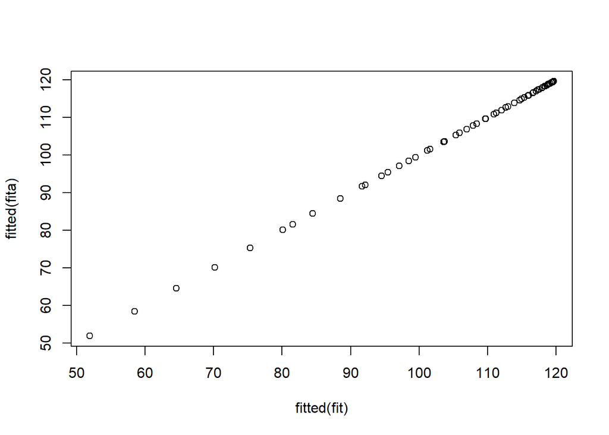

```r
plot(fitted(fit),fitted(fita)) # We can crudely check that the two fits are the same by doing a plot of the fitted values from our original polynomial model "fit" against "fita", and you see a perfectly straight line, which says those fitted values are at least closely the same
```

Again, by using orthogonal polynomials for “fit”, it turns out that we can separately test for each coefficient. So if we look at the summary again, we can see that the linear, quadratic and cubic terms are significant, but not the quartic.

```r
summary(fit)
```

```
##
## Call:
## lm(formula = wage ~ poly(age, 4), data = Wage)
##
## Residuals:
##     Min      1Q  Median      3Q     Max
## -98.707 -24.626  -4.993  15.217 203.693
##
## Coefficients:
##                Estimate Std. Error t value Pr(>|t|)
## (Intercept)    111.7036     0.7287 153.283  < 2e-16 ***
## poly(age, 4)1  447.0679    39.9148  11.201  < 2e-16 ***
## poly(age, 4)2 -478.3158    39.9148 -11.983  < 2e-16 ***
## poly(age, 4)3  125.5217    39.9148   3.145  0.00168 **
## poly(age, 4)4  -77.9112    39.9148  -1.952  0.05104 .
## ---
## Signif. codes:  0 '***' 0.001 '**' 0.01 '*' 0.05 '.' 0.1 ' ' 1
##
## Residual standard error: 39.91 on 2995 degrees of freedom
## Multiple R-squared:  0.08626,    Adjusted R-squared:  0.08504
## F-statistic: 70.69 on 4 and 2995 DF,  p-value: < 2.2e-16
```

This however only works with linear regression (i.e. this would not work with GLMs), and if there is a single predictor, therefore orthogonal polynomials have limited use. If you want to test whether, say, a one degree polynomial is better than another degree, you need to use the more general ANOVA function.

```r
fita=lm(wage~education,data=Wage)
fitb=lm(wage~education+age,data=Wage)
fitc=lm(wage~education+poly(age,2),data=Wage)
fitd=lm(wage~education+poly(age,3),data=Wage) # these are a nested sequence of models (i.e. the second model contains the variables from the first. The third model contains variables from the second and the first. And so on...)
anova(fita,fitb,fitc,fitd)
```

```
## Analysis of Variance Table
##
## Model 1: wage ~ education
## Model 2: wage ~ education + age
## Model 3: wage ~ education + poly(age, 2)
## Model 4: wage ~ education + poly(age, 3)
##   Res.Df     RSS Df Sum of Sq        F Pr(>F)
## 1   2995 3995721
## 2   2994 3867992  1    127729 102.7378 <2e-16 ***
## 3   2993 3725395  1    142597 114.6969 <2e-16 ***
## 4   2992 3719809  1      5587   4.4936 0.0341 *
## ---
## Signif. codes:  0 '***' 0.001 '**' 0.01 '*' 0.05 '.' 0.1 ' ' 1
```

### Polynomial logistic regression

Now we fit a logistic regression model to a binary response variable, constructed from `wage`. We code the big earners (`>250K`) as 1, else 0.

```r
fit=glm(I(wage>250) ~ poly(age,3), data=Wage, family=binomial) # We can create the binary target class on the fly using an indicator function, and in there we provide the condition, wage bigger than 250. That evaluates to a true / false variable, but if you coerce that to numeric it'll be a 0 / 1 variable.
summary(fit) # And now because it's a GLM, even though the polynomial is an orthogonal basis, it's no longer strictly orthogonal when we fit a GLM, because GLM involves having weights for the observations, and so the orthogonality is somewhat lost. Therefore we can't comment on the significance of one polynomial coefficient alone. If we want to do the test, for example, if a polynomial of degree 3 was needed, we'd have to fit another GLM with a polynomial of degree 2 and test to see if the two are different.
```

```
##
## Call:
## glm(formula = I(wage > 250) ~ poly(age, 3), family = binomial,
##     data = Wage)
##
## Deviance Residuals:
##     Min       1Q   Median       3Q      Max
## -0.2808  -0.2736  -0.2487  -0.1758   3.2868
##
## Coefficients:
##               Estimate Std. Error z value Pr(>|z|)
## (Intercept)    -3.8486     0.1597 -24.100  < 2e-16 ***
## poly(age, 3)1  37.8846    11.4818   3.300 0.000968 ***
## poly(age, 3)2 -29.5129    10.5626  -2.794 0.005205 **
## poly(age, 3)3   9.7966     8.9990   1.089 0.276317
## ---
## Signif. codes:  0 '***' 0.001 '**' 0.01 '*' 0.05 '.' 0.1 ' ' 1
##
## (Dispersion parameter for binomial family taken to be 1)
##
##     Null deviance: 730.53  on 2999  degrees of freedom
## Residual deviance: 707.92  on 2996  degrees of freedom
## AIC: 715.92
##
## Number of Fisher Scoring iterations: 8
```

```r
preds=predict(fit,list(age=age.grid),se=T)
se.bands=preds$fit + cbind(fit=0,lower=-2*preds$se,upper=2*preds$se)
se.bands[1:5,]
```

```
##         fit      lower     upper
## 1 -7.664756 -10.759826 -4.569686
## 2 -7.324776 -10.106699 -4.542852
## 3 -7.001732  -9.492821 -4.510643
## 4 -6.695229  -8.917158 -4.473300
## 5 -6.404868  -8.378691 -4.431045
```

We have done the computations on the logit scale. To transform we need to apply the inverse logit mapping
$$p=\frac{e^\eta}{1+e^\eta}.$$
(Here we have used the ability of MarkDown to interpret TeX expressions.) We can do this simultaneously for all three columns of `se.bands`:

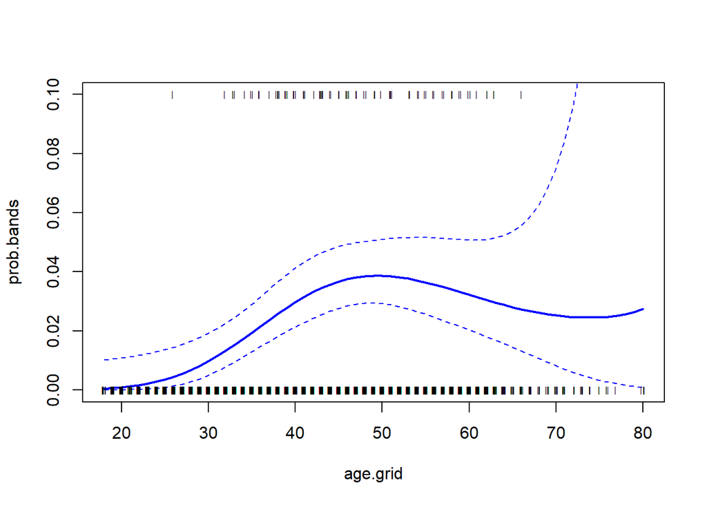

```r
prob.bands=exp(se.bands)/(1+exp(se.bands))
?matplot
matplot(age.grid,prob.bands,col="blue",lwd=c(2,1,1),lty=c(1,2,2),type="l",ylim=c(0,.1)) # we had to add y axis limits because the confidence bands get wide
points(jitter(age),I(wage>250)/10,pch="|",cex=.5) # Because there were lots of ties in age at each of the integer values of age, we use jitter of age to give an indication of how much data occurred at each age. Jitter randomly adds to each element of the vector age, a little bit of uniform random noise so you can get an idea of the density.
```

## Splines

Splines are more flexible than polynomials, but the idea is rather similar. Here we will explore cubic splines.

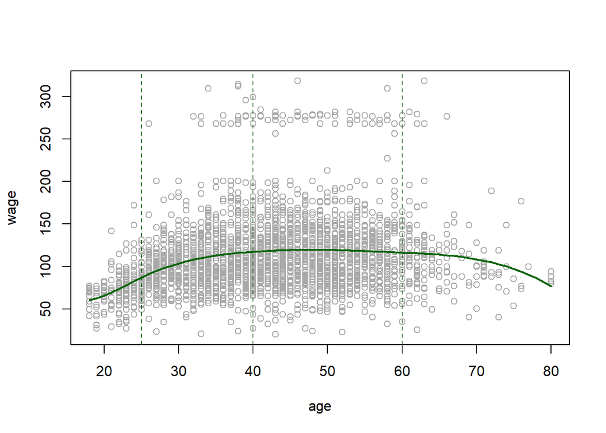

```r
library(splines)
fit=lm(wage~bs(age,knots=c(25,40,60)),data=Wage) # The knots (at ages = 25,40,60) are places of discontinuity. The spline has cubic polynomials in each of the regions, but they constrain to be continuous at the knots, and they are constrained to have continuous first and second derivatives, which makes them really smooth. In fact, so smooth that the human eye cannot detect the discontinuity. They're  discontinuous in the third derivative, so the idea of splines is that they're more local than polynomials. So they don't have quite the wagging tails of polynomials, and they're a nice way of fitting flexible functions.
plot(age,wage,col="darkgrey")
lines(age.grid,predict(fit,list(age=age.grid)),col="darkgreen",lwd=2)
abline(v=c(25,40,60),lty=2,col="darkgreen")
```

One step up from what we called fixed knot regression splines are smoothing splines. Smoothing splines are convenient because they have essentially knots everywhere, and they control how smooth a function is with the roughness penalty. The smoothing splines does not require knot selection, but it does have a smoothing parameter, which can conveniently be specified via the effective degrees of freedom or `df`.

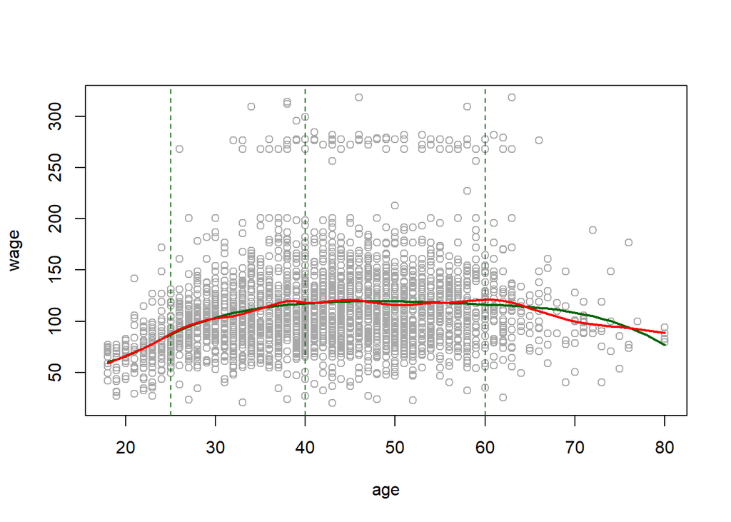

```r
## create original plot
fit=lm(wage~bs(age,knots=c(25,40,60)),data=Wage)
plot(age,wage,col="darkgrey")
lines(age.grid,predict(fit,list(age=age.grid)),col="darkgreen",lwd=2)
abline(v=c(25,40,60),lty=2,col="darkgreen")

## smoothing spline
fit=smooth.spline(age,wage,df=16) # higher df lead to a more spikey fit while lower df lead to a smoother fit
lines(fit,col="red",lwd=2)
```

Or we can use LOO cross-validation to select the smoothing parameter for us automatically:

```r
## create original plot
fit=lm(wage~bs(age,knots=c(25,40,60)),data=Wage)
plot(age,wage,col="darkgrey")
lines(age.grid,predict(fit,list(age=age.grid)),col="darkgreen",lwd=2)
abline(v=c(25,40,60),lty=2,col="darkgreen")
summary(fit) # counting the number of paramters, there are 6 degrees of freedom
```

```
##
## Call:
## lm(formula = wage ~ bs(age, knots = c(25, 40, 60)), data = Wage)
##
## Residuals:
##     Min      1Q  Median      3Q     Max
## -98.832 -24.537  -5.049  15.209 203.207
##
## Coefficients:
##                                 Estimate Std. Error t value Pr(>|t|)
## (Intercept)                       60.494      9.460   6.394 1.86e-10 ***
## bs(age, knots = c(25, 40, 60))1    3.980     12.538   0.317 0.750899
## bs(age, knots = c(25, 40, 60))2   44.631      9.626   4.636 3.70e-06 ***
## bs(age, knots = c(25, 40, 60))3   62.839     10.755   5.843 5.69e-09 ***
## bs(age, knots = c(25, 40, 60))4   55.991     10.706   5.230 1.81e-07 ***
## bs(age, knots = c(25, 40, 60))5   50.688     14.402   3.520 0.000439 ***
## bs(age, knots = c(25, 40, 60))6   16.606     19.126   0.868 0.385338
## ---
## Signif. codes:  0 '***' 0.001 '**' 0.01 '*' 0.05 '.' 0.1 ' ' 1
##
## Residual standard error: 39.92 on 2993 degrees of freedom
## Multiple R-squared:  0.08642,    Adjusted R-squared:  0.08459
## F-statistic: 47.19 on 6 and 2993 DF,  p-value: < 2.2e-16
```

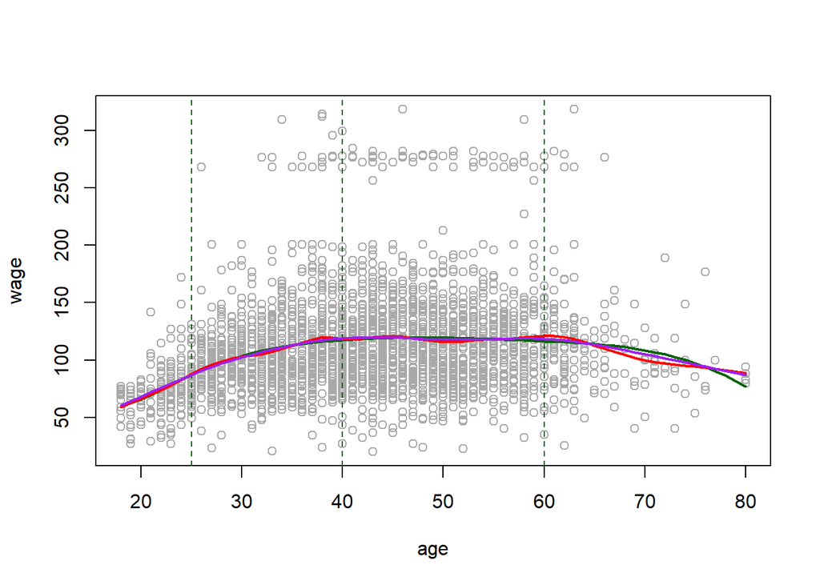

```r
## smoothing spline with 16 effective df
fit=smooth.spline(age,wage,df=16)
lines(fit,col="red",lwd=2)

## smoothing spline using LOO CV
fit=smooth.spline(age,wage,cv=TRUE) # notice we didn't specify the . A warning message does appear from the fit.
lines(fit,col="purple",lwd=2)
```

```r
fit # notice CV produced an effective degrees of freedom = 6.79
```

```
## Call:
## smooth.spline(x = age, y = wage, cv = TRUE)
##
## Smoothing Parameter  spar= 0.6988943  lambda= 0.02792303 (12 iterations)
## Equivalent Degrees of Freedom (Df): 6.794596
## Penalized Criterion (RSS): 75215.9
## PRESS(l.o.o. CV): 1593.383
```

## Generalized Additive Models

So far we have focused on fitting models with mostly single nonlinear terms. The `gam` package makes it easier to work with multiple nonlinear terms. In addition it knows how to plot these functions and their standard errors.

```r
library(gam)
gam1=gam(wage~s(age,df=4)+s(year,df=4)+education,data=Wage) # s() is a special function known to gam, and it tells gam it wants a smoothing spline in the variable age with four degrees of freedom, and likewise for the variable year
```

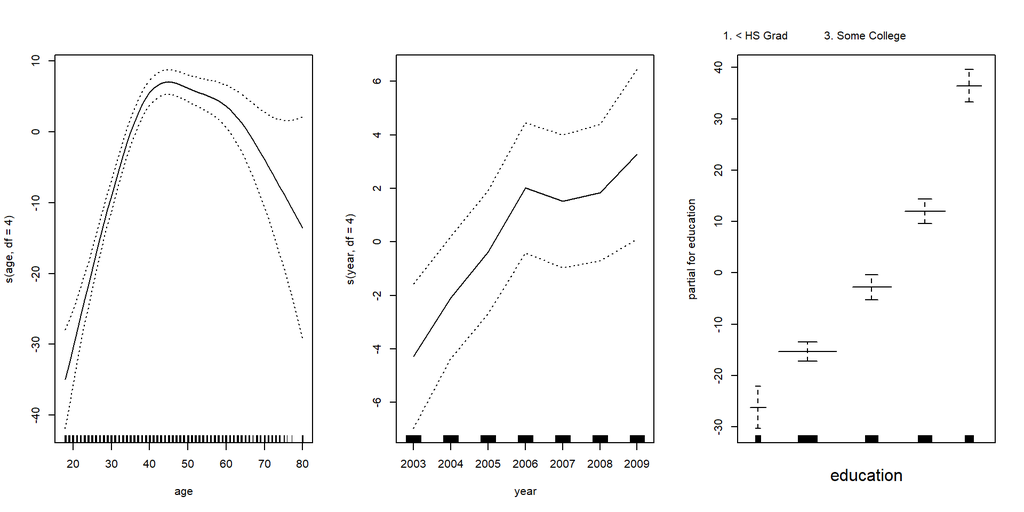

```r
par(mfrow=c(1,3)) # set up a plottign grid where we want 1 row, 3 columns
plot(gam1,se=T) # produce a plot for each of the terms in the gam, and plotted those terms with the standard errors for each of those terms
```

```r
gam2=gam(I(wage>250)~s(age,df=4)+s(year,df=4)+education,data=Wage,family=binomial)
```

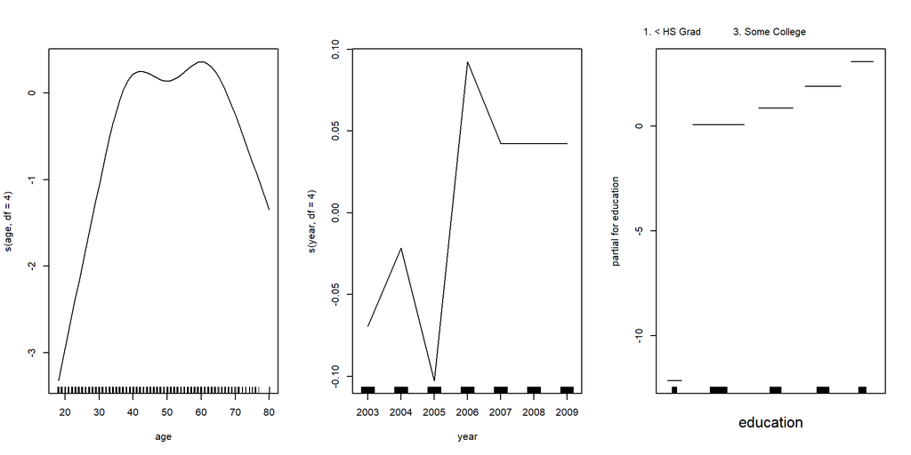

```r
plot(gam2) # We left out se=T since some of the standard error bands are really wide. This is plotting the contributions to the logit of the probability, each as the separate functions, since the model is additive in those.
```

We can test to see if we need a nonlinear terms for year

```r
gam2a=gam(I(wage>250)~s(age,df=4)+year+education,data=Wage,family=binomial) # instead of having a smooh term for year, we'll just jave a linear term
anova(gam2a,gam2,test="Chisq")
```

```
## Analysis of Deviance Table
##
## Model 1: I(wage > 250) ~ s(age, df = 4) + year + education
## Model 2: I(wage > 250) ~ s(age, df = 4) + s(year, df = 4) + education
##   Resid. Df Resid. Dev Df Deviance Pr(>Chi)
## 1      2990     603.78
## 2      2987     602.87  3  0.90498   0.8242
```

The p value is 0.82, which says we really don’t need this non-linear term for year. A linear term will be fine. If we wanted to, we can test further and see if you need a term at all for year.

One nice feature of the `gam` package is that it knows how to plot the functions nicely, even for models fit by `lm` and `glm`.

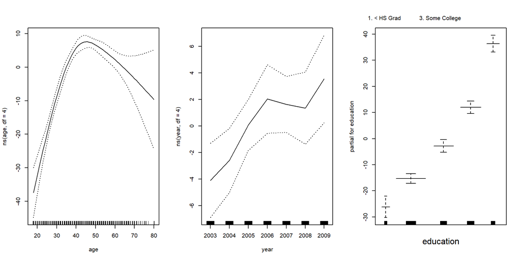

```r
par(mfrow=c(1,3))
lm1=lm(wage~ns(age,df=4)+ns(year,df=4)+education,data=Wage) # This looks like our gam() call but instead of s() we use ns() which is using a fixed basis (i.e. a reduced set of basis functions to represent the splines)
plot.Gam(lm1,se=T) # with software updates, plot.gam() is now plot.Gam(). Notice this plot looks very similar to the gam1=gam(wage~s(age,df=4)+s(year,df=4)+education,data=Wage). Make a habit to look in the changelogs of the package of interest if something doesn't work as expected: https://cran.r-project.org/web/packages/gam/ChangeLog
```